# Phases of Diapause Exit

Antdrew D. Nguyen, Evolutionary Physiologist

2018-01-10

# Introduction

Trying to make sense of Diapause exit. I’m imagining diapause exit as when organisms meet favorable conditions and then resume growth. When organisms meet favorable conditions, they first respond by terminating diapause (Kostal 2006) and and then resume growth. This trajectory can occur in a step wise fashion ( 2 phase, logistic then exponential) or continuously (1 phase, exponential). Here, I’m trying to make sense of these phases in a function-valued trait framework. The trajectory of diapause can be mapped by tracking metabolic rate, which can be measured continuously. Metabolic rate as a function of time has a certain shape then.

ref:

Kostal, V. (2006). Eco-physiological phases of insect diapause. Journal of Insect Physiology, 52, 113–127. https://doi.org/10.1016/j.jinsphys.2005.09.008

# One Phase Exit

ref: Wadsworth, C. B., Woods, W. A., Hahn, D. A., & Dopman, E. B. (2013). One phase of the dormancy developmental pathway is critical for the evolution of insect seasonality. Journal of Evolutionary Biology, 26(11), 2359–2368. https://doi.org/10.1111/jeb.12227

Wadsworth model for exponential increase:

$$R = e^{(t-a)^b} + c$$
where:

- a = presistent metabolic increase that defines the start of termination
- b = rate of metabolic increase during diapause termination
- c = initial metabolic rate during diapuse maintenance phase

Lets try to model this to see how these parameters can change the trajectory of diapause exit.

### Creating the plotting function

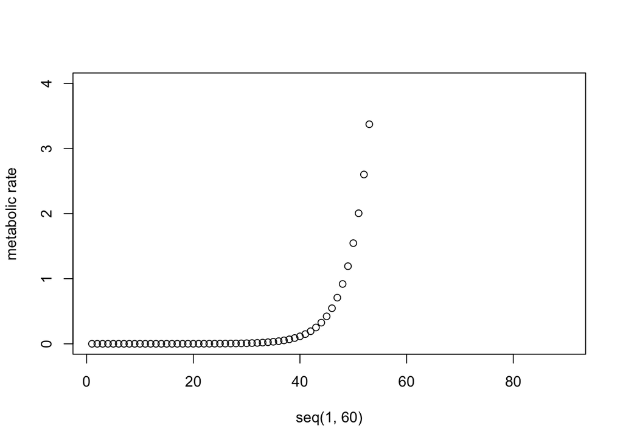

```r
Wad<-function(t=seq(1,60),a=12.9,b=.26,c=.95){
  #return(exp((t-a)^b)+c)
  return(exp((t-a))^b+c)
}
#Wad()

#orig function
plot(seq(1,60),Wad()*10^-4,ylim=c(0,4),xlim=c(1,90),ylab="metabolic rate")
```

### Messing with the a parameter

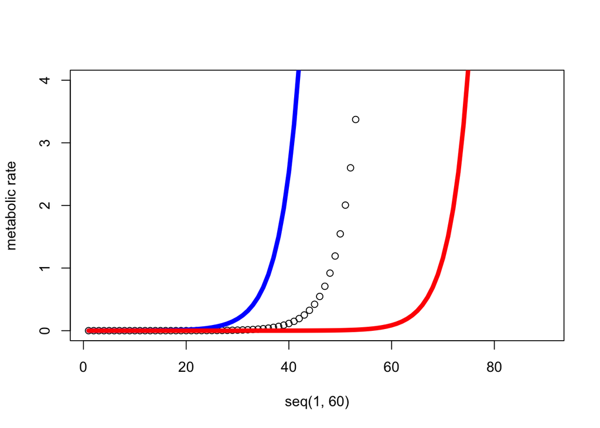

```r
#messing with a
plot(seq(1,60),Wad()*10^-4,ylim=c(0,4),xlim=c(1,90),ylab="metabolic rate")
lines(seq(1,60),Wad(a=1)*10^-4,ylim=c(0,4),col="blue",lwd=5) # shifts curve left
lines(seq(1,90),Wad(a=34,t=seq(1,90))*10^-4,ylim=c(0,4),col="red",lwd=5) # shifts curve right
```

**Larger values of a shifts the curve over to the right, higher values of time.** I’m using similar values as the paper, but not getting the same curve values. Relative differences still there.

### Messing with b parameter

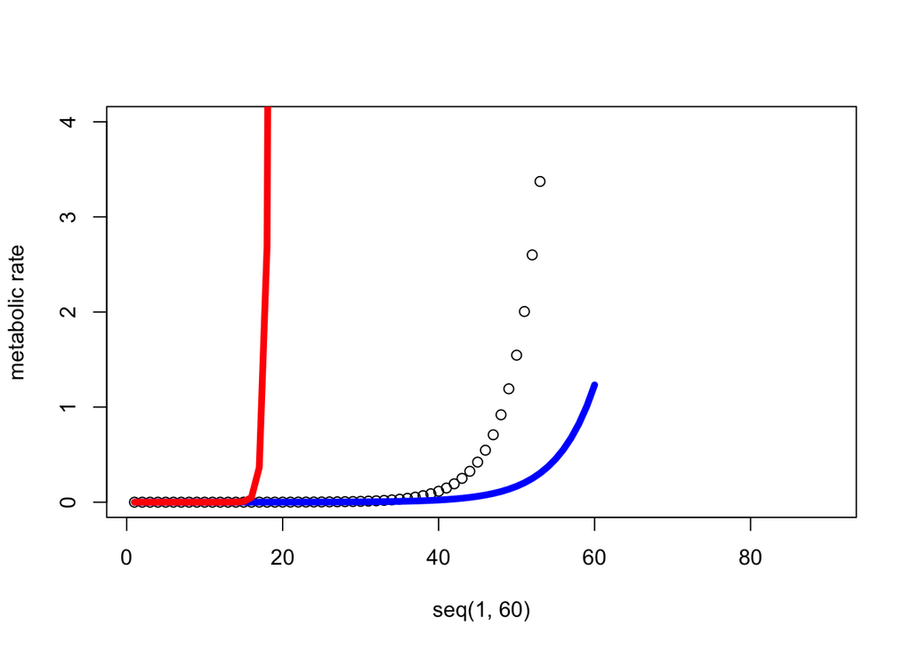

```r
# b parameter
plot(seq(1,60),Wad()*10^-4,ylim=c(0,4),xlim=c(1,90),ylab="metabolic rate")
lines(seq(1,60),Wad(b=.2)*10^-4,ylim=c(0,4),col="blue",lwd=5)
lines(seq(1,60),Wad(b=2,t=seq(1,60))*10^-4,ylim=c(0,4),col="red",lwd=5)
```

**Larger values make the curve steeper and shifts the curve to the left, earlier in time.** Why would they include this parameter, no clue.

### Messing with the c parameter

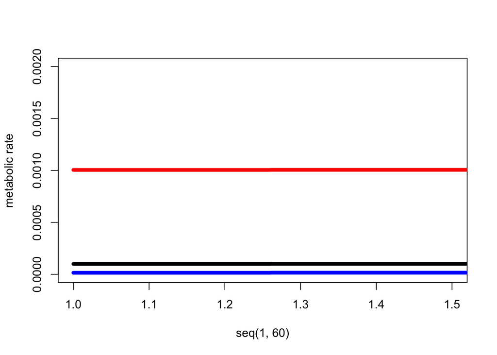

```r
plot(seq(1,60),Wad()*10^-4,ylim=c(0,.002),ylab="metabolic rate",xlim=c(1,1.5),type="n")
lines(seq(1,60),Wad()*10^-4,col="black",lwd=5)
lines(seq(1,60),Wad(c=.1)*10^-4,ylim=c(0,4),col="blue",lwd=5)
lines(seq(1,60),Wad(c=10,t=seq(1,60))*10^-4,ylim=c(0,4),col="red",lwd=5)
```

**Just adjusts the y intercept**

# Two Phase Exit

ref: Ragland, G. J., Fuller, J., Feder, J. L., & Hahn, D. A. (n.d.). Biphasic metabolic rate trajectory of pupal diapause termination and post-diapause development in a tephritid fly. https://doi.org/10.1016/j.jinsphys.2008.12.013

In this paper, Rhagoletis first undergo an logistic increase in metabolic rate, followed by an exponential increase.

Ragland biphase model:

$$R = \frac{\alpha}{(1+\beta e^{-t})} + c e^{at} + b$$
where:

- R = respiration rate
- t = time in days out of witner treatment
- c = fitted scaling parameter
- $\alpha$ = resp rate at the transition between logistic to exponential increase
- $\beta$ = the timing of the initial logistic increase
- a = timing of transition between logistic and expo increase
- b = diapause baseline

> where R is the respiration rate, t the time in days out of winter treatment, c is a fitted scaling parameter, and alpha, beta, a, and b are fitted parameters that determine respiration rate at the transition between the logistic and exponential increase, the timing of the initial logistic increase, the timing of the transition between logistic and exponential increase, and the diapausing baseline respiration rate, respectively.

### Creating plotting function

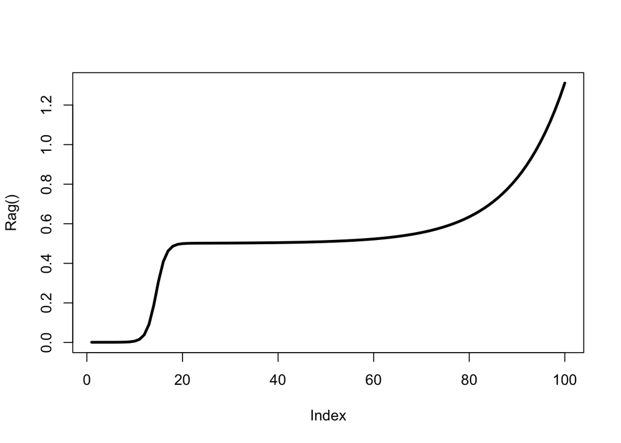

```r
Rag<-function(t=seq(1,100),c=.1,beta=2000000,alpha=500,a=.09,b=1){
  R= ((alpha)/(1+(beta*exp(-t))))+c*exp(a*t)+b
  return(R*10^-3)
}
#Rag()
plot(Rag(),type="n",ylim=c())
lines(seq(1,100),Rag(),lwd=3)
```

## Logistic increase

### Messing with alpha , $\alpha$

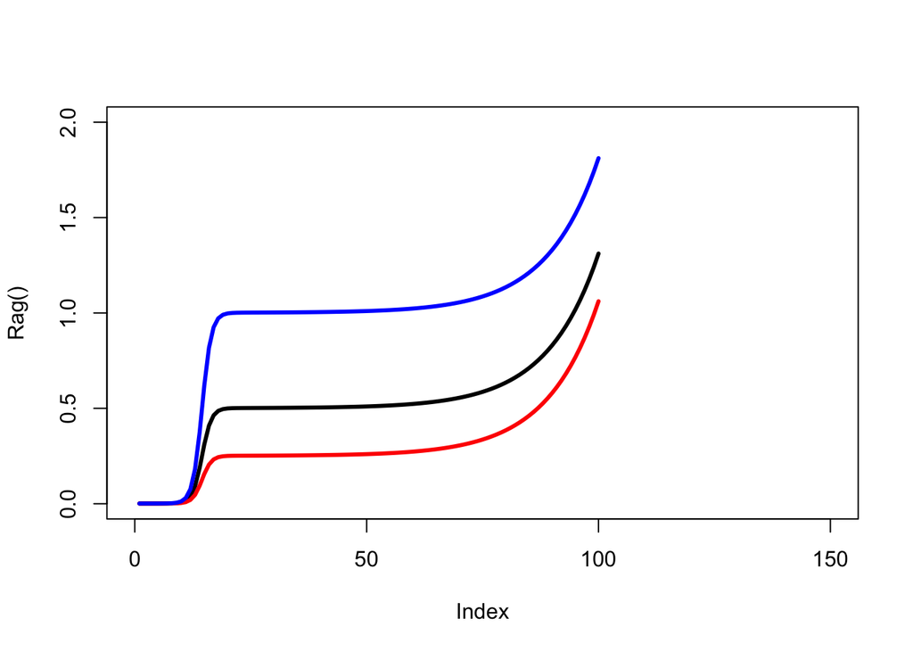

```r
plot(Rag(),type="n",xlim=c(0,150),ylim=c(0,2))
lines(seq(1,100),Rag(),lwd=3)
lines(seq(1,100),Rag(alpha=250),lwd=3,col="red")
lines(seq(1,100),Rag(alpha=1000),lwd=3,col="blue")
```

**Modulates the plateau phase or stationary phase of logistic part of curve**

### Messing with beta, $\beta$

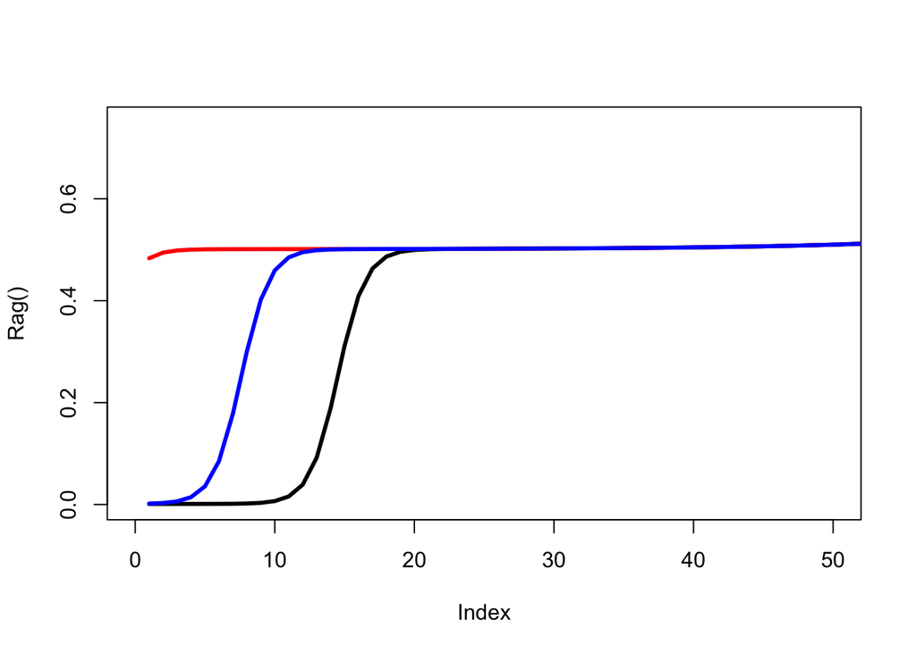

```r
plot(Rag(),type="n",ylim=c(0,.75),xlim=c(0,50))
lines(seq(1,100),Rag(),lwd=3)
lines(seq(1,100),Rag(beta=.1),lwd=3,col="red")
lines(seq(1,100),Rag(beta=2000),lwd=3,col="blue")
```

## Exponential increase

### Messing with c, scaling parameter

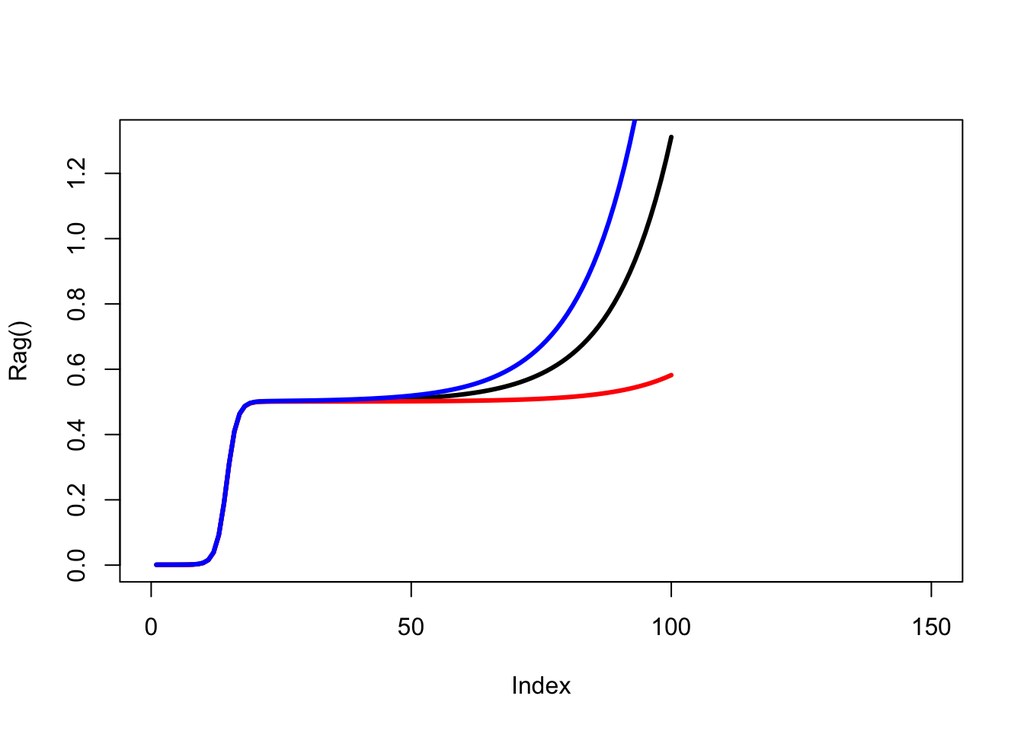

```r
plot(Rag(),type="n",ylim=c(),xlim=c(0,150))
lines(seq(1,100),Rag(),lwd=3)
lines(seq(1,100),Rag(c=.01),lwd=3,col="red")
lines(seq(1,100),Rag(c=.2),lwd=3,col="blue")
```

**Modulates the exponential increase**

### Messing with a, timing of transition between logistic and expo increase

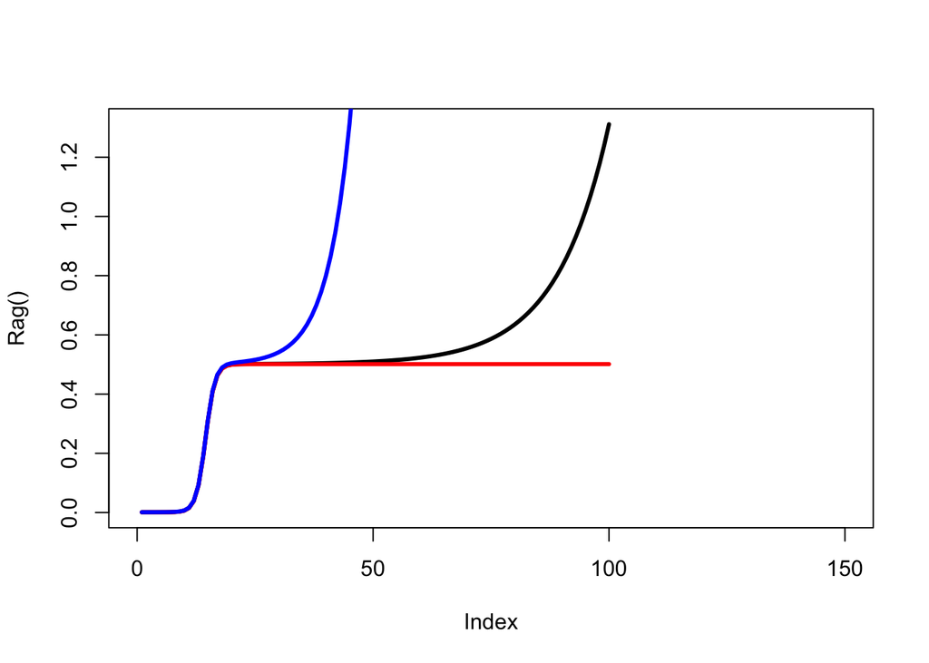

```r
plot(Rag(),type="n",ylim=c(),xlim=c(0,150))
lines(seq(1,100),Rag(),lwd=3)
lines(seq(1,100),Rag(a=.01),lwd=3,col="red")
lines(seq(1,100),Rag(a=.2),lwd=3,col="blue")
```

**Modulates the timing of exp increase**

# Thoughts

Exit to diapause influences the emergence patterns in wild populations and is therefore an important phenotype for understanding how organisms can differentiate throughout a season. It looks like organisms can exit diapause differently. ECB has one phase, while Rhagoletis has two phases. Although Rhagoletis is two steps, the immediate increase in metabolic rate signifies or is a hallmark of termination. And termination itself adaptively varies among strains(ECB) and races (Rhagoletis) and may facilitate and enable speciation.